# Machine Learning for Acoustics Summer School 2019

## Step 5: Evaluation

At this point of the challenge - kind of ~3.5 hours in with ~1 hour remaining - we received the evaluation set.

```python
## Load data - Evaluation
data_evaluation = loadmat('ML_challenge_wave_data_evaluation.mat')

X_evaluation = data_evaluation['wave'] # nxd matrix, n: num of ultrasonic pulses collected, d: num of data points in each wave
xyz_evaluation = data_evaluation['xyz'] # nx3 matrix, n: num of observations along the rows and , x,y,z coordinates along the columns
```

```
The matrix X has dimensions:  (50, 2048)
The matrix xyz has dimensions:  (50, 3)
```

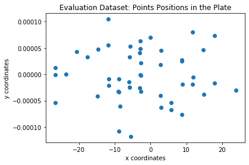

```python
## Let's look at the data
print('The matrix X has dimensions: ',np.shape(X_evaluation))
print('The matrix xyz has dimensions: ',np.shape(xyz_evaluation))

# How the points are placed in the plate
plt.figure()
plt.plot(xyz_evaluation[:,0], X_evaluation[:,1], 'o')
plt.title('Evaluation Dataset: Points Positions in the Plate')
plt.xlabel('x coordinates')
plt.ylabel('y coordinates')
print('')
```

OK. So, we have 50 new points, with positions in random locations of the plate.

### Features Extraction

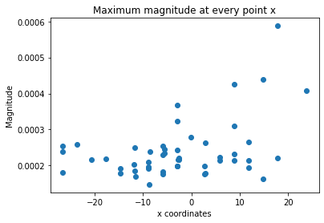

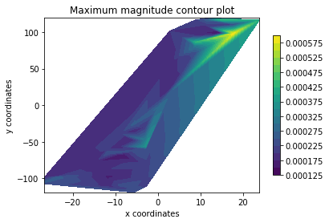

```python
## Feature 1: maximum absolute amplitude of each point vibration over time
max_amp_feature_eval = np.max(np.abs(X_evaluation), axis = 1) # axis=1 because we calculate it along the x axis

## Plot features from your data in xyz coordinates

plt.figure()
plt.plot(xyz_evaluation[:,0], max_amp_feature_eval[:], 'o')
plt.title('Maximum magnitude at every point x')
plt.xlabel('x coordinates')
plt.ylabel('Magnitude')

plt.figure()
plt.tricontourf(xyz_evaluation[:,0], xyz_evaluation[:,1], max_amp_feature_eval, 20)
plt.title('Maximum magnitude contour plot')
plt.xlabel('x coordinates')
plt.ylabel('y coordinates')
plt.colorbar(shrink = 0.8)
print('')
```

Doesn't look good, the amplitude seems quite low, but hard to say anything at this point.

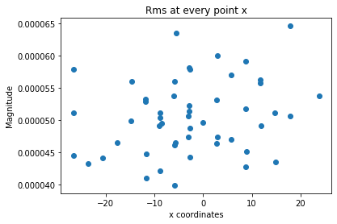

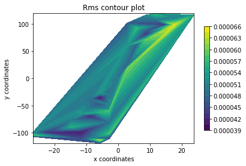

```python
## Feature 2: rms of each point vibration over time
rms_feature_eval = np.sqrt(np.mean(X_evaluation**2, axis = 1)) # axis=1 because we calculate it along the x axis
## Plot features from your data in xyz coordinates

plt.figure()
plt.plot(xyz_evaluation[:,0], rms_feature_eval[:], 'o')
plt.title('Rms at every point x')
plt.xlabel('x coordinates')
plt.ylabel('Magnitude')

plt.figure()
plt.tricontourf(xyz_evaluation[:,0], xyz_evaluation[:,1], rms_feature_eval,20)
plt.title('Rms contour plot')
plt.xlabel('x coordinates')
plt.ylabel('y coordinates')
plt.colorbar(shrink = 0.8)
print('')
```

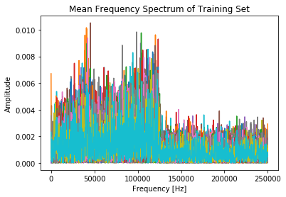

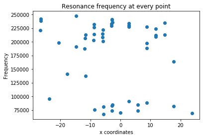

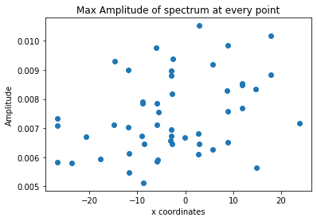

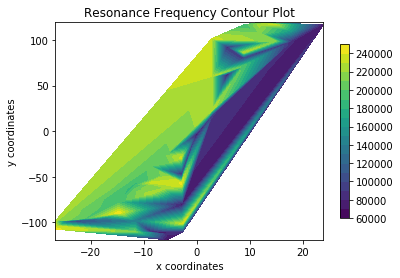

```python
## Feature 3 and 4: extract resonance frequencies of the signals and max amplitude at the resonances
# Initialize a fft matrix with same dimensions as the training set
X_eval_shape = np.shape(X_evaluation)
fft_X_eval = np.zeros(X_eval_shape)


# Fill each row of the FFT matrix with a Fast Fourier Transform of each signal in X_train
for iRow in range(X_eval_shape[0]):
    fft_X_eval[iRow] = syfp.fft(X_evaluation[iRow, :])

# Sample Rate as provided in the challenge text (1 MHz)
SR_eval = 1*10**6

# Length of the original signals
N_eval = X_eval_shape[1]

# Avoid aliasing by multiplying sampling frequency by 1/2 and form frequency vector
f_eval = np.linspace(0, 0.5*SR_eval, N_eval)

# Plot frequency spectrum against amplitude for each point in the data set


plt.figure()
plt.ylabel("Amplitude")
plt.xlabel("Frequency [Hz]")
for iRow in range(50):
    plt.plot(f_eval[:N // 2], np.abs(fft_X_eval)[iRow,:N // 2])
plt.title("Mean Frequency Spectrum of Training Set")


# Assign the value of the fft to a temporary matrix
fft_temp_eval = np.abs(fft_X_eval[:,:N // 2])
fft_temp_shape_eval = np.shape(fft_temp_eval)

# Feature 3: max amplitude in the frequency spectrum for each point
fft_feature_amp_eval = np.zeros(fft_temp_shape_eval[0])

# Feature 4: index corresponding to the max amplitude, i.e. resonance frequency of every point
fft_feature_index_eval = np.zeros(fft_temp_shape_eval[0])

# For every point in the training set, calculate the frequency which has the maximum amplitude (fft_feature_index)
# and its amplitude (fft_feature_ampliude)
for i in range(fft_temp_shape_eval[0]):
    fft_feature_amp_eval[i] = np.max(np.abs(fft_temp_eval[i,:]))
    fft_feature_index_eval[i] = np.multiply(np.divide(np.argmax(np.abs(fft_temp_eval[i,:])), fft_temp_shape_eval[1]), SR_eval/2)

# Plot the maximum frequency of vibration of every point
plt.figure()
plt.plot(xyz_evaluation[:,0], fft_feature_index_eval, 'o')
plt.title('Resonance frequency at every point')
plt.xlabel('x coordinates')
plt.ylabel('Frequency')

# Plot the amplitude of each max frequency
plt.figure()
plt.plot(xyz_evaluation[:,0], fft_feature_amp_eval, 'o')
plt.title('Max Amplitude of spectrum at every point')
plt.xlabel('x coordinates')
plt.ylabel('Amplitude')

# Plot the maximum frequency of every point in a contour plot
plt.figure()
plt.tricontourf(xyz_evaluation[:,0], xyz_evaluation[:,1], fft_feature_index_eval,20)
plt.title('Resonance Frequency Contour Plot')
plt.xlabel('x coordinates')
plt.ylabel('y coordinates')
plt.colorbar(shrink = 0.8)
print('')
```

All right, also here everything seems a bit off, but still hard to tell. Let's plot the scattered plots over the density and see.

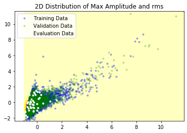

```python
# Features 1 and 2

max_amp_feature_eval = (max_amp_feature_eval - np.mean(max_amp_feature_eval))/np.std(max_amp_feature_eval)
rms_feature_eval = (rms_feature_eval - np.mean(rms_feature_eval))/np.std(rms_feature_eval)

x_eval_rms_amp = np.array([max_amp_feature_eval,rms_feature_eval])
x_eval_rms_amp = np.transpose(x_eval_rms_amp)

# Plot the density and the training points
den_levels_amp_rms = np.sqrt(np.std(den_train_amp_rms))*np.array([1,2,3])
#den_levels_amp_rms = 1.2*np.percentile(den_train_amp_rms, range(0,100,5))
plt.figure()
#plt.tricontourf(x_test_amp_rms[:,0], x_test_amp_rms[:,1], den_test_amp_rms, levels=den_levels_amp_rms, cmap = 'hot_r')
plt.tricontourf(x_test_amp_rms[:,0], x_test_amp_rms[:,1], den_test_amp_rms, cmap = 'hot_r')
#The above output is made so that the final image consists of 100x100 with an intensity value for each pixel
# plt.tripcolor(x_test[:,0], x_test[:,1], den_test, cmap = 'afmhot_r')

plt.plot(x_train_amp_rms[:,0],x_train_amp_rms[:,1], '.b',alpha=0.3, label = 'Training Data')
plt.plot(x_val_rms_amp[:,0],x_val_rms_amp[:,1], '.g',alpha=0.2, label = 'Validation Data')
plt.plot(x_eval_rms_amp[:,0],x_eval_rms_amp[:,1], '.w',alpha=1, label = 'Evaluation Data')
plt.title('2D Distribution of Max Amplitude and rms')
plt.legend(loc = 'upper left')
print('')
```

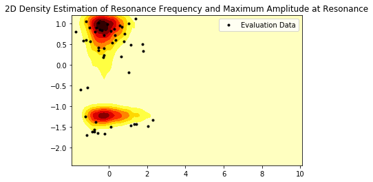

```python
# Features 3 and 4

fft_feature_amp_eval = (fft_feature_amp_eval - np.mean(fft_feature_amp_eval))/np.std(fft_feature_amp_eval)
fft_feature_index_eval = (fft_feature_index_eval - np.mean(fft_feature_index_eval))/np.std(fft_feature_index_eval)



x_eval_fft_amp = np.array([fft_feature_amp_eval,fft_feature_index_eval])
x_eval_fft_amp = np.transpose(x_eval_fft_amp)


# Plot the density and the training points
den_levels_fft_amp = np.sqrt(np.std(den_train_fft_amp))*np.array([1,2,3])
#den_levels_fft_amp = 1.2*np.percentile(den_train_fft_amp, range(0,100,5))
plt.figure()
#plt.tricontourf(x_test_fft_amp[:,0], x_test_fft_amp[:,1], den_test_fft_amp, levels=den_levels_fft_amp, cmap = 'hot_r')
plt.tricontourf(x_test_fft_amp[:,0], x_test_fft_amp[:,1], den_test_fft_amp, cmap = 'hot_r')
#The above output is made so that the final image consists of 100x100 with an intensity value for each pixel
# plt.tripcolor(x_test[:,0], x_test[:,1], den_test, cmap = 'afmhot_r')
plt.title('2D Density Estimation of Resonance Frequency and Maximum Amplitude at Resonance')

#plt.plot(x_train_fft_amp[:,0],x_train_fft_amp[:,1], '.b',alpha=0.3)
#plt.plot(x_val_fft_amp[:,0],x_val_fft_amp[:,1], '.g',alpha=0.2)
plt.plot(x_eval_fft_amp[:,0],x_eval_fft_amp[:,1], '.k',alpha=1, label = 'Evaluation Data')
plt.legend(loc='upper right')
#plt.savefig('EvaluationFreqDensity.png')
print('')
```

Just after a quick look at this figure, I can count around ~23 points that do not fit well into the model. But more insight can be gained in the discussion.

```
The number of abnormal points is:  23

Their index is:  [5452, 5456, 5458, 5461, 5462, 5463, 5467, 5472, 5473, 5474, 5475, 5476, 5479, 5484, 5485, 5486, 5488, 5491, 5495, 5496, 5498, 5499, 5501]

Since the length of the full data set is  (5502,) all the abnormal point belong to the evaluation set.
```

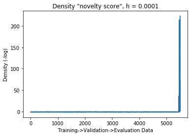

```python
# Now train on training and validation dataset, predict on all the data

# Training on fft and amp training features
x_train_final = np.array([np.concatenate((fft_feature_amp, fft_feature_amp_val)),np.concatenate((fft_feature_index, fft_feature_index_val))])
x_train_final = x_train_final.transpose()

# Testing on all the data
fft_feature_amp_final = np.concatenate((fft_feature_amp, fft_feature_amp_val,fft_feature_amp_eval))
fft_feature_index_final = np.concatenate((fft_feature_index, fft_feature_index_val, fft_feature_index_eval))

x_test_final = np.array([fft_feature_amp_final,fft_feature_index_final])
x_test_final = x_test_final.transpose()

h_final_23=0.0001
den_test_final_23 = kernel_density_rbf(x_train_final,x_test_final, h_final_23)


# lets reshape the density so that it defines a positive "novelty score"
density_score = -np.log(den_test_final_23)
plt.plot(density_score)
plt.title('Density "novelty score", h = 0.0001')
plt.xlabel('Training->Validation->Evaluation Data')
plt.ylabel('Density (-log)')

abnormal_count = 0
abnormal_count_ind = []

for iCount in range(np.shape(fft_feature_amp_final)[0]):
    if density_score[iCount]>5:
        abnormal_count = abnormal_count + 1
        abnormal_count_ind.append(iCount)



print('The number of abnormal points is: ', abnormal_count)
print(' ')
print('Their index is: ', abnormal_count_ind)
print(' ')
print('Since the length of the full data set is ', np.shape(fft_feature_amp_final), 'all the abnormal point belong to the evaluation set.')
```

```
[0, 4, 6, 9, 10, 11, 15, 20, 21, 22, 23, 24, 27, 32, 33, 34, 36, 39, 43, 44, 46, 47, 49]
```

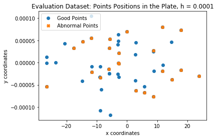

```python
# How the points are placed in the plate
abnormal_count_ind_new = []
abnormal_count_ind_new[:] = [x - 5502 + 50 for x in abnormal_count_ind]

print(abnormal_count_ind_new)

plt.figure()
plt.plot(xyz_evaluation[:,0], X_evaluation[:,1], 'o', label = 'Good Points')
plt.plot(xyz_evaluation[abnormal_count_ind_new[:],0], X_evaluation[abnormal_count_ind_new[:],1], 'X', label = 'Abnormal Points')
plt.title('Evaluation Dataset: Points Positions in the Plate')
plt.xlabel('x coordinates')
plt.ylabel('y coordinates')
plt.legend(loc='upper left')
plt.title('Evaluation Dataset: Points Positions in the Plate, h = 0.0001')
```

This all looks good! But let's do one last attempt before the final conclusions.

```
The number of abnormal points is:  49

Their index is:  [5452, 5453, 5454, 5455, 5456, 5457, 5458, 5459, 5460, 5461, 5462, 5463, 5464, 5465, 5466, 5467, 5468, 5469, 5470, 5471, 5472, 5473, 5474, 5475, 5476, 5477, 5478, 5479, 5480, 5481, 5482, 5483, 5484, 5485, 5486, 5487, 5488, 5489, 5490, 5491, 5492, 5493, 5495, 5496, 5497, 5498, 5499, …

Since the length of the full data set is  (5502,) all the abnormal point belong to the evaluation set.
[0, 1, 2, 3, 4, 5, 6, 7, 8, 9, 10, 11, 12, 13, 14, 15, 16, 17, 18, 19, 20, 21, 22, 23, 24, 25, 26, 27, 28, 29, 30, 31, 32, 33, 34, 35, 36, 37, 38, 39, 40, 41, 43, 44, 45, 46, 47, 48, 49]
```

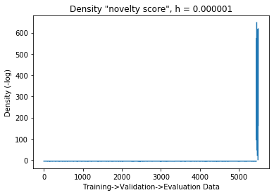

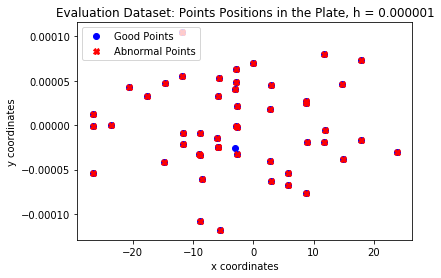

```python
# Now train on training and validation dataset, predict on all the data

# Training on fft and amp training features
x_train_final = np.array([np.concatenate((fft_feature_amp, fft_feature_amp_val)),np.concatenate((fft_feature_index, fft_feature_index_val))])
x_train_final = x_train_final.transpose()

# Testing on all the data
fft_feature_amp_final = np.concatenate((fft_feature_amp, fft_feature_amp_val,fft_feature_amp_eval))
fft_feature_index_final = np.concatenate((fft_feature_index, fft_feature_index_val, fft_feature_index_eval))

x_test_final = np.array([fft_feature_amp_final,fft_feature_index_final])
x_test_final = x_test_final.transpose()

h_final_49=0.000001
den_test_final_49 = kernel_density_rbf(x_train_final,x_test_final, h_final_49)


# lets reshape the density so that it defines a positive "novelty score"
density_score = -np.log(den_test_final_49)
plt.figure()
plt.plot(density_score)
plt.title('Density "novelty score", h = 0.000001')
plt.xlabel('Training->Validation->Evaluation Data')
plt.ylabel('Density (-log)')
#plt.savefig('DensityScore.png')

abnormal_count = 0
abnormal_count_ind = []

for iCount in range(np.shape(fft_feature_amp_final)[0]):
    if density_score[iCount]>5:
        abnormal_count = abnormal_count + 1
        abnormal_count_ind.append(iCount)



print('The number of abnormal points is: ', abnormal_count)
print(' ')
print('Their index is: ', abnormal_count_ind)
print(' ')
print('Since the length of the full data set is ', np.shape(fft_feature_amp_final), 'all the abnormal point belong to the evaluation set.')

# How the points are placed in the plate
abnormal_count_ind_new = []
abnormal_count_ind_new[:] = [x - 5502 + 50 for x in abnormal_count_ind]

print(abnormal_count_ind_new)

#plt.figure(figsize=(10,8))
plt.figure()
plt.plot(xyz_evaluation[:,0], X_evaluation[:,1], 'ob', label = 'Good Points')
plt.plot(xyz_evaluation[abnormal_count_ind_new[:],0], X_evaluation[abnormal_count_ind_new[:],1], 'Xr', label = 'Abnormal Points')
plt.legend(loc='upper left')
plt.title('Evaluation Dataset: Points Positions in the Plate, h = 0.000001')
plt.xlabel('x coordinates')
plt.ylabel('y coordinates')
#plt.savefig('PointsDistribution.png')
```

Ha! Now, the number of damaged point is 50 (technically here is 49, but for h = 0.0000001 it's 50 - but it won't show a nice graph). One interesting point is that I had to train the final model with both training and validation data to obtain 49 points in the density score. It is also worth noting that all the results were possible by manually tweacking the hyperparameter.

## Step 6: Discussion and Conclusion

[output not shown]

4) Final insight: in this case an answer was provided, so when I obtained a model that gave me 50 abnormal points I was happy. In real life though, nobody will tell us what the solution of a problem really is. In this case, the only way to really verify that our points are damaged is to be sure that we have identified meaninguful features that change due to a crack. I guess that my point is, humans are still needed - for now - and they'd better know acoustics!